# 01-molecular-drug-test

Sara Gosline

5/18/2020

Here we have an example of using the `Xeva` package to search for any molecular indicates of drug response in the MPNST PDX data.

## Load PDX Data

PDX data is available on [this Synapse project page](https://www.synapse.org/#!Synapse:syn21984813/wiki/602362) that collates available PDX and tumor model data across the project.

For this project we use the `Xeva` xenograft visualization and analysis tool to test out initial hypotheses of gene expression and mutation correlation.

```
## [1] "specimenID"            "individualID"          "sex"
## [4] "species"               "experimentalCondition"
## [1] "individualID" "specimenID"   "tranche"
## # A tibble: 45 x 4
##    model.id           patient.id biobase.id       mDataType
##    <chr>              <chr>      <chr>            <chr>
##  1 2-002_Doxorubinsin JHU002     JHU002 xenograft RNASeq
##  2 2-002_Doxorubinsin JHU002     JHU002_xenograft mutation
##  3 2-002_Doxorubinsin JHU002     JHU002_tumor     mutation
##  4 2-002_Everolimus   JHU002     JHU002 xenograft RNASeq
##  5 2-002_Everolimus   JHU002     JHU002_xenograft mutation
##  6 2-002_Everolimus   JHU002     JHU002_tumor     mutation
##  7 2-002_Vehicle      JHU002     JHU002 xenograft RNASeq
##  8 2-002_Vehicle      JHU002     JHU002_xenograft mutation
##  9 2-002_Vehicle      JHU002     JHU002_tumor     mutation
## 10 PDX1_Doxorubinsin  WU356      WU356_tumor      RNASeq
## # ... with 35 more rows
## Drug columns are
## drug
```

We currently have rnaSeq and drug-sensitivity for 6 PDX models. We can plot the tumor volume data is shown here.

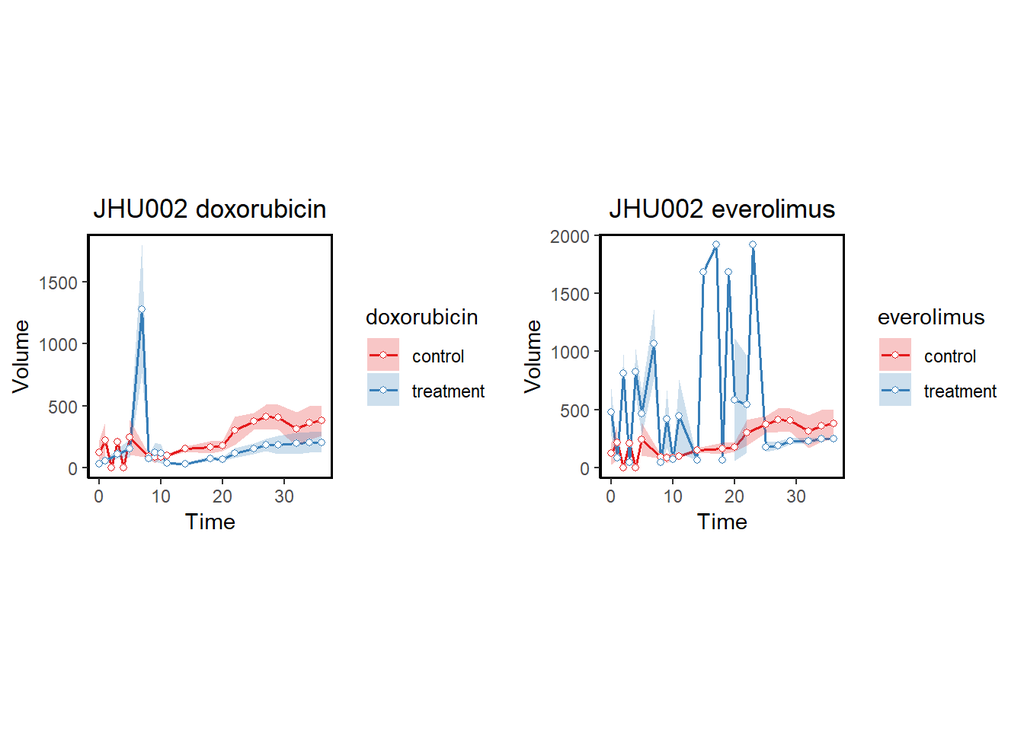

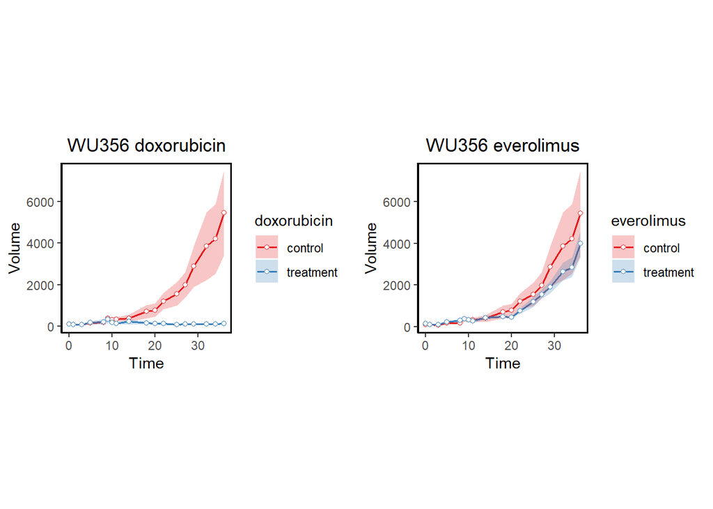

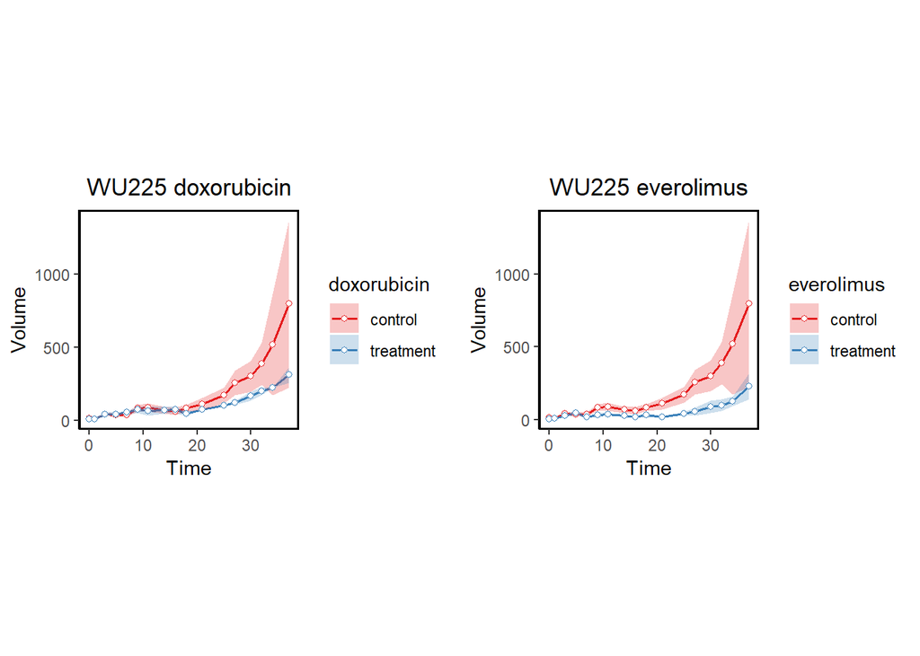

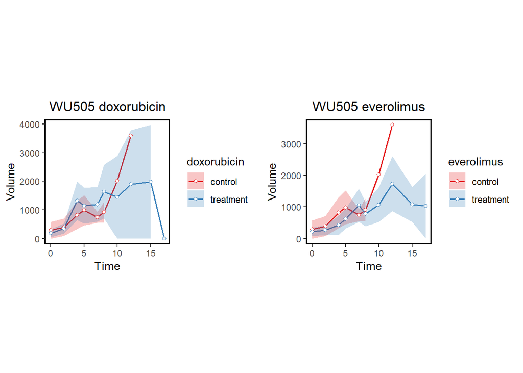

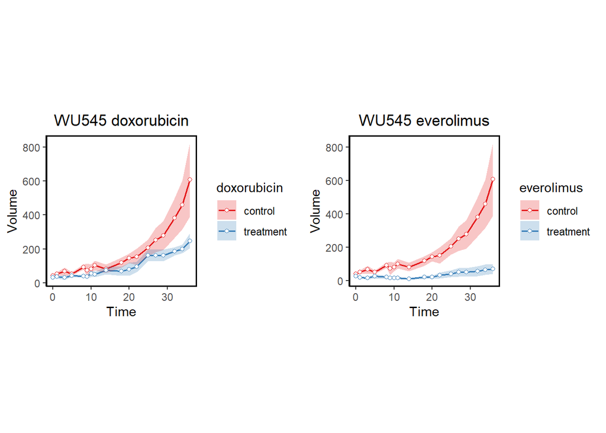

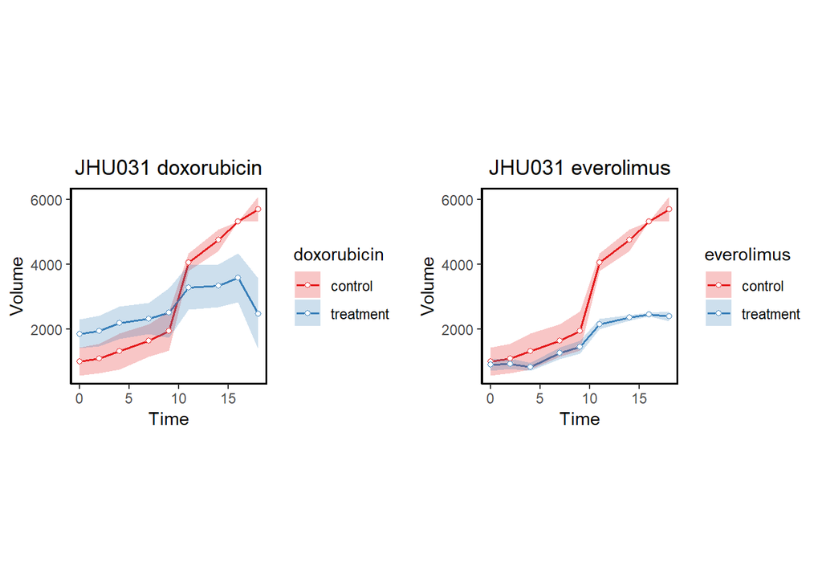

## Use statistics to correlate gene expression

First we want to assess the respnse variables for each PDX/drug combination.

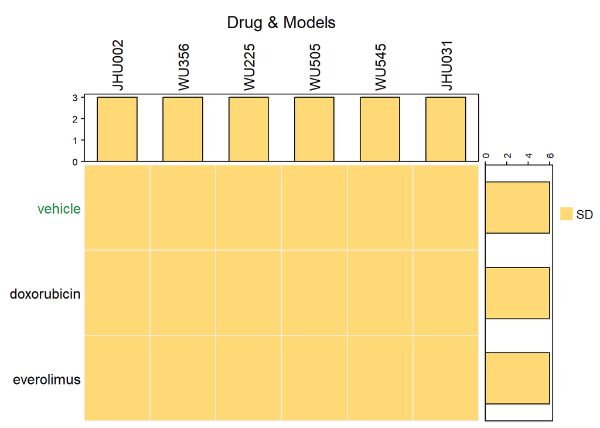

## Molecular correlations

Using `Xeva` we can load the molecular data and calculate the correlation of each transcript to the slope of the response data.

```
##   feature       drug   estimate           se n       tstat       fstat
## 1    HAS1 everolimus -1.0000000 5.544608e-06 3 -180355.413 32528075032
## 2   STIM2 everolimus  1.0000000 2.026547e-05 3   49345.030  2434931980
## 3    MADD everolimus -1.0000000 3.367203e-05 3  -29698.235   881985159
## 4  LRRTM4 everolimus -1.0000000 2.273153e-04 3   -4399.176    19352750
## 5    KRT5 everolimus  0.9999999 3.259529e-04 3    3067.928     9412182
## 6   P2RX7 everolimus -0.9999999 4.945287e-04 3   -2022.127     4088998
##         pvalue df        fdr
## 1 3.529807e-06  1 0.06357535
## 2 1.290140e-05  1 0.11618352
## 3 2.143628e-05  1 0.12869630
## 4 1.447134e-04  1 0.42990716
## 5 2.075081e-04  1 0.42990716
## 6 3.148268e-04  1 0.42990716
```

```
##   feature        drug   estimate           se n      tstat    fstat
## 1 SLC38A6 doxorubicin -1.0000000 0.0002114946 3 -4728.2526 22356373
## 2  RIPOR1 doxorubicin -1.0000000 0.0002229287 3 -4485.7392 20121856
## 3  ANKLE2 doxorubicin -0.9999999 0.0003991489 3 -2505.3303  6276680
## 4  SYCE1L doxorubicin  0.9999999 0.0004393840 3  2275.9132  5179781
## 5 TUBGCP2 doxorubicin -0.9999996 0.0008977008 3 -1113.9565  1240899
## 6   STIM1 doxorubicin -0.9999994 0.0010625127 3  -941.1647   885791
##         pvalue df       fdr
## 1 0.0001346417  1 0.8521169
## 2 0.0001419208  1 0.8521169
## 3 0.0002541061  1 0.8521169
## 4 0.0002797206  1 0.8521169
## 5 0.0005714941  1 0.8521169
## 6 0.0006764167  1 0.8521169
```

Now we can look at the mutational data in more detail

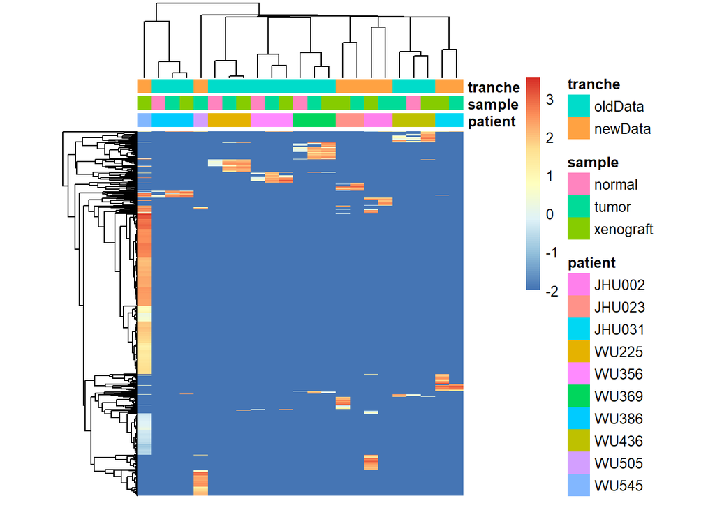

We then select for those mutations that exist in more than one sample. And then add back TP53.

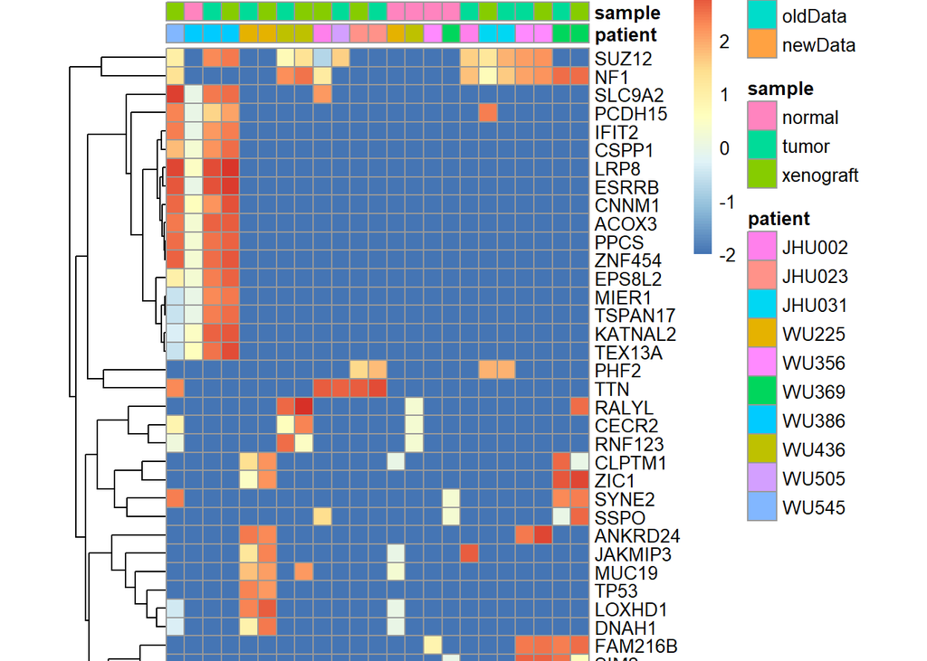

We can also plot the gene expression.

We can also plot how the genes are expressed

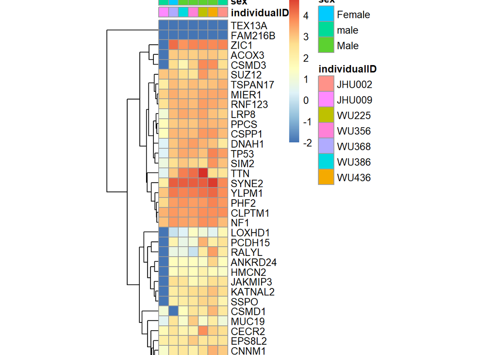